# What are my habits of the songs I add to my spotify playlists?

Lillie Carter

## The goal!

Throughout this project, I wish to try and understand the habits I uptake according to the songs I add to my Spotify playlists. This can be exemplified in detail throughout this project via analysing what type of song titles I am more drawn to, what average length of song and release year I add most to my playlists, and how I rate these particular songs on a scale of 1-10 based on what type of playlist I add them to.

## Data Collection!

To collect this data I filled out a Google Form with certain facts about the types of songs I add to my Spotify playlists. Including answers a range of different questions about the type of song - such as its name, the artist, facts about it’s type of record and what I would rate the song on a scale of 1 to 10 - Google Forms also track a timestamp of when I submit the form, which can also be helpful in observing what times of the day I am most likely to add a song to my playlist.

## How long has this data been collected for?

In order to collect the data for this project, I utilised some preexisting data as per prior task instructions for Project 2. So, in order to explore this, this bar chart represents what data was collected for Project 2, and what additional data was added in order to further explore this topic for this project (Project 4). This idea was exempified through analysing what hour (on a 24-hour scale) each data point was added to this data collection.

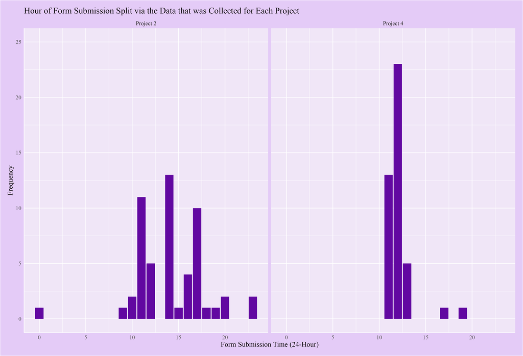

Bar chart split into songs that I added for Project 2 vs. Project 4 based on the hour I submit the form.

As we can see here, the data collected for Project 2 expands over a rather vast range of hours compared to the data collected for Project 4! This is mostly because at the start of this project, I had to catch-up with the songs I added to my playlist as I had stopped filling out the Google Form after the completion of Project 2. This explains the smaller range of hours within the data for Project 4 as it was collected over a tighter period of time.

## Analysing Song Titles: How many characters and words are in song titles?

First, I wanted to explore how the song titles that I add to my playlists are constructed. This is displayed through this graph, in where I count how many words and characters are within a song title, split via whether they are on an Album, EP, or Single.

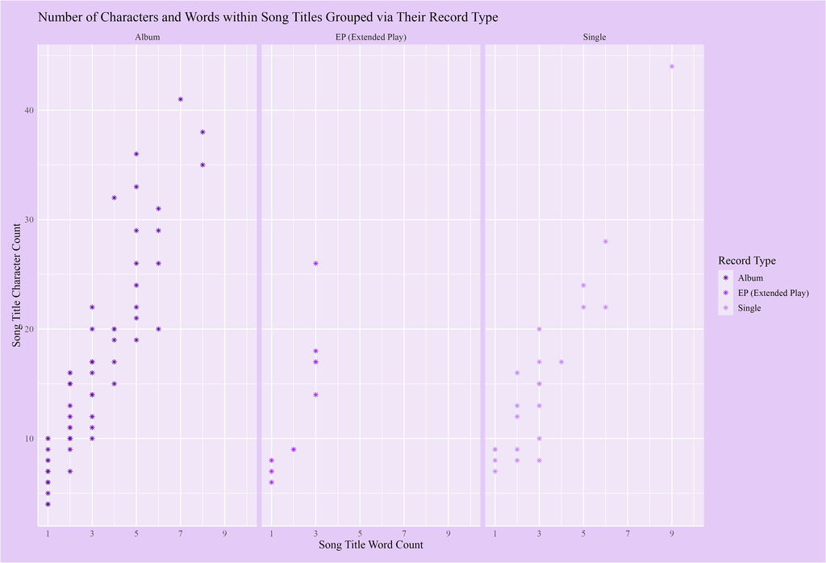

Scatter graph split into the different record types (Album, EP, or Single) showing the word and character lengths of song titles.

Based on the visuals in this graph, we can see that Albums tend to have long word and character counts compared to both EP’s and Singles. However, this cannot be generalised as of yet as there is significantly more data points within the Album level compared to EP’s and Singles, which is biased. Despite this, I can make the conclusion on my Spotify habits that I seem to be more drawn to songs that are on Albums compared to those that are released on a EP or Single.

## How long are songs, compared to the year they were released?

Secondly, I wanted to observe the length of the songs I add to my playlists by what year they are released. As per the graph below, my data is grouped by the year the song was released and the average song length for each year. The size of the point is then exemplified by how many songs within the concurrent year contribute to the average song length.

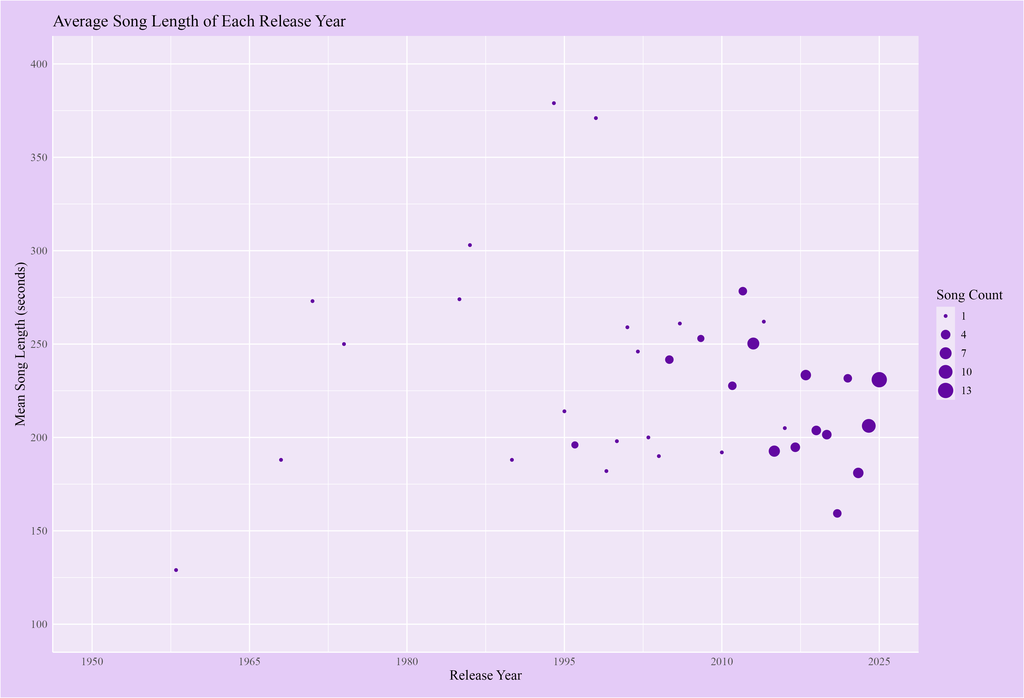

Scatter graph showing the release year of songs and their average song length, also counting how many values contribute to the average song length within each year.

By looking at this graph, there is a higher count of songs from around 2010-2025, compared to those that were released before 2010. This can contribute to the fact that I mostly listen to songs that have been released more recently, compared to those that are older. A claim I can make from this observation about my Spotify habits is that I mostly listen to songs that are released within the last 10 years compared to those released before then.

## How are songs rated across each of my playlist types?

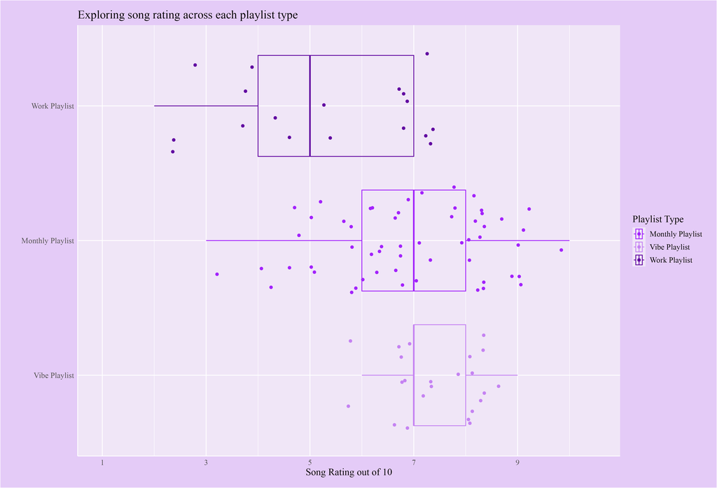

Boxplot showing my personal rating of songs spread across the playlist type I add them to.

Upon looking at the visuals of this boxplot, it appears as though I rate songs lower if they are present in my Work Playlist. This is likely because I add a lot of songs to my Work Playlist that I know my coworkers enjoy, even if I might not like the song that much. Additionally, I seem to rate songs much higher for those I add to my monthly playlist and playlist based on a certain vibe - which makes sense as I willing add songs to the playlists that I know I already enjoy.